# S. pennellii RNAseq simulations

Julin Maloof

July 22, 2016

# Introduction

# Overall Question

When mapping RNAseq reads from a heterologous species to a reference genome, what is the best way to perform the mapping?

For example:

- We have a tomato reference genome
- We want to do RNAseq on a variety of wild relatives of tomato for which we have no genome

# Strategy: simulation

- Use *S. pennellii* and *S. lycopersium*. Both are sequenced.
- Simulate RNASeq reads from *S. pennellii* and map to *S. lycopersicum*.
- Compare actual (simulated) counts to the number of counts that map.
- Can compare different aligners:
  - stampy
  - [subread](http://bioinf.wehi.edu.au/subread/)
  - STAR
  - [bowtie2](http://bowtie-bio.sourceforge.net/bowtie2/index.shtml)
  - [BWA](http://bio-bwa.sourceforge.net/)
  - [Kallisto](https://pachterlab.github.io/kallisto/)
- And different parameters with those aligners.

# Preliminaries

# Install Polyester

Use the [Polyester package](http://bioconductor.org/packages/release/bioc/vignettes/polyester/inst/doc/polyester.html) to simulate RNAseq reads. Also see the [Polyester paper.](http://bioinformatics.oxfordjournals.org/content/31/17/2778)

Installation. Only needs to be run once per computer.

```r
source("http://bioconductor.org/biocLite.R")
biocLite("polyester")
```

# Install STAR (only needs to be done once)

```bash
brew install rna-star
brew install gcc5
```

# load libraries and helper scripts

```r
library(polyester)
library(Biostrings)
```

```r
library(ggplot2)
library(Rsamtools)
library(rtracklayer)
library(Rsubread)
library(R.utils)
library(plyr)
setwd("~/Documents/Lab Notebook support/2015/rnaseq_simulations")
source("Rnaseq_sim_helper_functions.R")
```

# Simluate reads (simple version)

Load Spen and Slyc transcripts  
Spen CDS fasta can be obtained from SGN slyc fasta is also from SGN

```r
pen.transcripts <-  readDNAStringSet("~/Sequences/ref_genomes/S.pen/Spenn-v2-cds-annot.fa")
head(pen.transcripts)
```

```
##   A DNAStringSet instance of length 6
##     width seq                                          names
## [1]   264 ATGCGGGTCTATGAGACTGTA...GGCGAACTGAAAGATCTTAG Sopen00g001010.1 ...
## [2]   294 ATGCCTGTTTTACTAGGCGCG...TTAGCGGGCGACAAGCGTAG Sopen00g001020.1 ...
## [3]   798 ATGATTGAATCTCAGAGGCAT...ATTGGTGGGGAGGTATATGA Sopen00g001030.1 ...
## [4]   693 ATGGAACTTTCTCCCCGAGCT...AAGCGAANGGACGTCGGTAA Sopen00g001040.1 ...
## [5]   951 ATGCCCAATAAAAGTAAAAGA...AGAATAAAGAATTTGAATAG Sopen00g001050.1 ...
## [6]   393 ATGATTTGTTTTATGGACAGT...GTTGCTGCTTCCACAGCTAA Sopen00g001060.1 ...
```

```r
names(pen.transcripts[1:10])
```

```
##  [1] "Sopen00g001010.1 hypothetical protein"
##  [2] "Sopen00g001020.1 hypothetical protein"
##  [3] "Sopen00g001030.1 Cytochrome c oxidase subunit III"
##  [4] "Sopen00g001040.1 ATP synthase alpha/beta family, beta-barrel domain"
##  [5] "Sopen00g001050.1 Mitochondrial ATP synthase B chain precursor (ATP-synt_B)"
##  [6] "Sopen00g001060.1 hypothetical protein"
##  [7] "Sopen00g001070.1 hypothetical protein"
##  [8] "Sopen00g001080.1 hypothetical protein"
##  [9] "Sopen00g001090.1 Reverse transcriptase (RNA-dependent DNA polymerase)"
## [10] "Sopen00g001100.1 Domain of unknown function (DUF4283)"
```

```r
lyc.transcripts <- readDNAStringSet("~/Sequences/ref_genomes/tomato/ITAG2.4_Chromo2.5/ITAG2.4_cds.fasta")
head(lyc.transcripts)
```

```
##   A DNAStringSet instance of length 6
##     width seq                                          names
## [1]  1401 ATGTTTGTCCCTTCAATATTT...TTGGCCCTAATATTTGCTAG Solyc00g005000.2....
## [2]   486 ATGTATGTTATATGTAAATGT...CAGTACGTGGATTCAAATAG Solyc00g005020.1....
## [3]   357 ATGGAAGCTGAATACTTCCCT...ATTATCCACTGTTTTTTTAA Solyc00g005040.2....
## [4]   588 ATGGCGGTGAATCCTCAACTA...CATACCAGTCAACCAGCTGA Solyc00g005050.2....
## [5]   273 ATGCTAGTGTGTGTTGGGGTT...TTAAGGCACTACGCCTCTAG Solyc00g005060.1....
## [6]    81 ATGCTTCTAGCTTGGACTGGA...GACTAGCTTCTTATGTTTAG Solyc00g005070.1....
```

```r
names(lyc.transcripts)[1:10]
```

```
##  [1] "Solyc00g005000.2.1 genomic_reference:SL2.50ch00 gene_region:16437-18189 transcript_region:SL2.50ch00:16437..18189+ go_terms:GO:0006508 functional_description:\"Aspartic proteinase nepenthesin I (AHRD V1 **-- A9ZMF9_NEPAL); contains Interpro domain(s)  IPR001461  Peptidase A1 \""
##  [2] "Solyc00g005020.1.1 evidence_code:10F0H0E0IEG genomic_reference:SL2.50ch00 gene_region:68062-68764 transcript_region:SL2.50ch00:68062..68764+ functional_description:\"Unknown Protein (AHRD V1)\""
##  [3] "Solyc00g005040.2.1 genomic_reference:SL2.50ch00 gene_region:550920-551576 transcript_region:SL2.50ch00:550920..551576+ functional_description:\"Potassium channel (AHRD V1 ***- D0EM91_9ROSI); contains Interpro domain(s)  IPR000595  Cyclic nucleotide-binding \""
##  [4] "Solyc00g005050.2.1 genomic_reference:SL2.50ch00 gene_region:570544-575454 transcript_region:SL2.50ch00:570544..575454- functional_description:\"Arabinogalactan protein (AHRD V1 ***- B6SST2_MAIZE)\""
##  [5] "Solyc00g005060.1.1 evidence_code:10F0H0E0IEG genomic_reference:SL2.50ch00 gene_region:723746-724018 transcript_region:SL2.50ch00:723746..724018- functional_description:\"Unknown Protein (AHRD V1)\""
##  [6] "Solyc00g005070.1.1 evidence_code:10F0H0E0IEG genomic_reference:SL2.50ch00 gene_region:755300-755543 transcript_region:SL2.50ch00:755300..755543- functional_description:\"Unknown Protein (AHRD V1)\""
##  [7] "Solyc00g005080.1.1 evidence_code:10F0H1E0IEG genomic_reference:SL2.50ch00 gene_region:791493-792010 transcript_region:SL2.50ch00:791493..792010- functional_description:\"Ycf2 (AHRD V1 ***- A6YA23_9MAGN)\""
##  [8] "Solyc00g005090.1.1 evidence_code:10F0H0E0IEG genomic_reference:SL2.50ch00 gene_region:1061638-1061922 transcript_region:SL2.50ch00:1061638..1061922- functional_description:\"Unknown Protein (AHRD V1)\""
##  [9] "Solyc00g005100.1.1 evidence_code:10F0H0E0IEG genomic_reference:SL2.50ch00 gene_region:1115784-1117712 transcript_region:SL2.50ch00:1115784..1117712+ functional_description:\"Unknown Protein (AHRD V1)\""
## [10] "Solyc00g005110.1.1 evidence_code:10F0H0E0IEG genomic_reference:SL2.50ch00 gene_region:1124582-1125325 transcript_region:SL2.50ch00:1124582..1125325- functional_description:\"Unknown Protein (AHRD V1)\""
```

# Reformat names to get rid of description and add Slyc reference

```r
orthologs <- read.delim("Ortho_v2.txt",header=FALSE) #From Tony Bolger
head(orthologs)
```

```
##                  V1                 V2
## 1 Sopen03g006680.t1 Solyc04g024690.1.1
## 2 Sopen08g027370.t1 Solyc08g078910.1.1
## 3 Sopen05g001030.t1 Solyc05g005020.2.1
## 4 Sopen03g037380.t1 Solyc03g118500.2.1
## 5 Sopen06g031780.t1 Solyc06g075360.2.1
## 6 Sopen04g003290.t1 Solyc04g008120.1.1
```

```r
names(orthologs) <- c("PEN","LYC")
orthologs$PEN <- sub("t","",orthologs$PEN)
orthologs$PEN.LYC <- paste(orthologs$PEN,orthologs$LYC,sep="_")
names(pen.transcripts) <- substr(names(pen.transcripts),1,16)
names(pen.transcripts) <- ifelse(!is.na(match(names(pen.transcripts),orthologs$PEN)),
                                 orthologs$PEN.LYC[match(names(pen.transcripts),orthologs$PEN)],
                                 names(pen.transcripts))
pen.transcripts
```

```
##   A DNAStringSet instance of length 48923
##         width seq                                      names
##     [1]   264 ATGCGGGTCTATGAGACTG...CGAACTGAAAGATCTTAG Sopen00g001010.1_...
##     [2]   294 ATGCCTGTTTTACTAGGCG...AGCGGGCGACAAGCGTAG Sopen00g001020.1
##     [3]   798 ATGATTGAATCTCAGAGGC...TGGTGGGGAGGTATATGA Sopen00g001030.1_...
##     [4]   693 ATGGAACTTTCTCCCCGAG...GCGAANGGACGTCGGTAA Sopen00g001040.1_...
##     [5]   951 ATGCCCAATAAAAGTAAAA...AATAAAGAATTTGAATAG Sopen00g001050.1_...
##     ...   ... ...
## [48919]  3924 ATGTCTGCTTTGAACGTGA...AACATCAGAAGCTGTTAA Sopen12g034990.1
## [48920]  3810 ATGGATAGTTCGAAGCTTG...CATCGTGATGAAGGCTGA Sopen12g035000.1
## [48921]   345 ATGAATCTTGGAGGCATAA...ATACAGAGTAAACTTTAG Sopen12g035010.1_...
## [48922]   447 ATGTCGTTAACATATTTTC...GGTCATACTCACACATAA Sopen12g035020.1
## [48923]  6429 ATGGAAGGAAATGAGCATG...AGTCTTGAAACTTTATAA Sopen12g035030.1_...
```

```r
names(lyc.transcripts) <- substr(names(lyc.transcripts),1,18)
names(lyc.transcripts) <- ifelse(!is.na(match(names(lyc.transcripts),orthologs$LYC)),
                                 orthologs$PEN.LYC[match(names(lyc.transcripts),orthologs$LYC)],
                                 names(lyc.transcripts))
pen.gene.length <- as.integer(nchar(pen.transcripts))
names(pen.gene.length) <- names(pen.transcripts)
lyc.gene.length <- as.integer(nchar(lyc.transcripts))
names(lyc.gene.length) <- names(lyc.transcripts)
```

# Limit ourselves to genes where orthology is clear:

```r
pen.transcripts.small <- pen.transcripts[nchar(names(pen.transcripts))>16]
lyc.transcripts.small <- lyc.transcripts[nchar(names(lyc.transcripts)) > 18]

if(! file.exists("~/Sequences/ref_genomes/S.pen/Spenn-v2-cds-annot_orthlogs_only.fa")) writeXStringSet(pen.transcripts.small,file="~/Sequences/ref_genomes/S.pen/Spenn-v2-cds-annot_orthlogs_only.fa")

if(! file.exists("~/Sequences/ref_genomes/tomato/ITAG2.4_Chromo2.5/ITAG2.4_cds.pen.orthologs.only.fasta")) writeXStringSet(lyc.transcripts.small,file="~/Sequences/ref_genomes/tomato/ITAG2.4_Chromo2.5/ITAG2.4_cds.pen.orthologs.only.fasta")
```

# Simulate PEN RNAseq reads

```r
#3 minutes for 1M reads
#15 minutes for 5M reads
system.time(
  simulate_experiment(fasta="~/Sequences/ref_genomes/S.pen/Spenn-v2-cds-annot_orthlogs_only.fa",
                      outdir="spen_sim_2",
                      num_reps=1,
                      readlen=45,
                      #line below gives ~ 10M reads, scaled by transcript length and following a rexp distribution
                      reads_per_transcript = round(rexp(n=length(pen.transcripts.small)) * width(pen.transcripts.small) *
                                                     1e7/ sum(width(pen.transcripts.small) ))+1,
                      paired=FALSE,
                      error_model="illumina5",
                      bias="rnaf"
  )
)
system("sed 's!/!;!' spen_sim_2/sample_01.fasta > spen_sim_2/sample_01_renamed.fasta") #this allows original gene_names to be kept
system("rm spen_sim_2/sample_01.fasta")
system("gzip spen_sim_2/sample_01_renamed.fasta")
```

# Simulate LYC RNAseq reads

```r
system.time(
  simulate_experiment(fasta="~/Sequences/ref_genomes/tomato/ITAG2.4_Chromo2.5/ITAG2.4_cds.pen.orthologs.only.fasta",
                      outdir="slyc_sim_2",
                      num_reps=1,
                      readlen=45,
                      #line below gives ~ 10M reads, scaled by transcript length and following a rexp distribution
                      reads_per_transcript = round(rexp(n=length(lyc.transcripts.small)) * width(lyc.transcripts.small) *
                                                     1e7/ sum(width(lyc.transcripts.small) ))+1,
                      paired=FALSE,
                      error_model="illumina5",
                      bias="rnaf"
  )
)
system("sed 's!/!;!' slyc_sim_2/sample_01.fasta > slyc_sim_2/sample_01_renamed.fasta") #this allows original gene_names to be kept
system("rm slyc_sim_2/sample_01.fasta")
system("gzip slyc_sim_2/sample_01_renamed.fasta")
```

# calculate known counts

Use external python script

```r
pen.known.counts <- read.table(pipe("./CountGene.py spen_sim_2/sample_01_renamed.fasta.gz"),col.names=c("id","count"),stringsAsFactors = FALSE)
pen.known.counts$lyc.id <- substr(pen.known.counts$id,18,33)
head(pen.known.counts)
```

```
##                                    id count           lyc.id
## 1 Sopen07g034180.1_Solyc07g065980.2.1  2771 Solyc07g065980.2
## 2 Sopen11g004230.1_Solyc11g008440.1.1   120 Solyc11g008440.1
## 3 Sopen02g006420.1_Solyc02g022830.2.1   746 Solyc02g022830.2
## 4 Sopen08g029390.1_Solyc08g081070.2.1   673 Solyc08g081070.2
## 5 Sopen12g002150.1_Solyc12g006190.1.1   219 Solyc12g006190.1
## 6 Sopen08g024690.1_Solyc08g076040.1.1   279 Solyc08g076040.1
```

```r
lyc.known.counts <- read.table(pipe("./CountGene.py slyc_sim_2/sample_01_renamed.fasta.gz"),col.names=c("id","count"),stringsAsFactors = FALSE)
lyc.known.counts$lyc.id <- substr(lyc.known.counts$id,18,33)
head(lyc.known.counts)
```

```
##                                    id count           lyc.id
## 1 Sopen10g026850.1_Solyc10g062180.1.1   553 Solyc10g062180.1
## 2 Sopen01g052320.1_Solyc01g110160.2.1   233 Solyc01g110160.2
## 3 Sopen03g002160.1_Solyc03g006150.2.1   378 Solyc03g006150.2
## 4 Sopen08g002520.1_Solyc08g006560.2.1  1067 Solyc08g006560.2
## 5 Sopen03g032230.1_Solyc03g113170.1.1   114 Solyc03g113170.1
## 6 Sopen07g030860.1_Solyc07g062630.1.1   697 Solyc07g062630.1
```

# Map with star

# Create genome file

Only needs to be done once  
This is a shell command  
Takes about 25 minutes

```bash
gffread -T ITAG2.4_gene_models.gff3 -o ITAG2.4_gene_models.gtf
STAR --runThreadN 6 --runMode genomeGenerate --genomeDir ~/Sequences/ref_genomes/tomato/ITAG2.4_Chromo2.5/STAR_genome --genomeFastaFiles ~/Sequences/ref_genomes/tomato/ITAG2.4_Chromo2.5/S_lycopersicum_chromosomes.2.50.fa --sjdbGTFfile ~/Sequences/ref_genomes/tomato/ITAG2.4_Chromo2.5/ITAG2.4_gene_models.gtf
```

# Create parameters files

```bash
cat > STAR.params.whitney.1
genomeDir /Network/Servers/avalanche.plb.ucdavis.edu/Volumes/Mammoth/Users/jmaloof/Sequences/ref_genomes/tomato/ITAG2.4_Chromo2.5/STAR_genome
outSAMtype BAM SortedByCoordinate
outSAMunmapped Within
quantMode GeneCounts
```

# Run it!

```r
RunStar(fasta="sample_01_renamed.fasta.gz",prefix = "STAR_1", param.file = "../STAR.params.whitney.1", dir="spen_sim_2",n=12)
RunStar(fasta="sample_01_renamed.fasta.gz",prefix = "STAR_1", param.file = "../STAR.params.whitney.1", dir="slyc_sim_2",n=12)
```

# Evaluate results from STAR

# We want to do:

- correlation between known counts and found counts
- how many reads map to the wrong gene?
- how many reads do not map?
- are the splice junctions correct?

# Load in mapped counts

```r
#using the STAR built-in counter
#pen.mapped.counts.STAR <- GetMappedCounts(prefix = "STAR_1", dir = "spen_sim_2")
#lyc.mapped.counts.STAR <- GetMappedCounts(prefix = "STAR_1", dir = "slyc_sim_2")
#using featureCounts from Rsubread
pen.mapped.counts <- GetMappedCounts(prefix = "STAR_1", dir = "spen_sim_2", type="STAR-featureCounts")
```

[output not shown]

```r
lyc.mapped.counts <- GetMappedCounts(prefix = "STAR_1", dir = "slyc_sim_2", type="STAR-featureCounts")
```

[output not shown]

# *S. pennellii*

Compare known to mapped counts

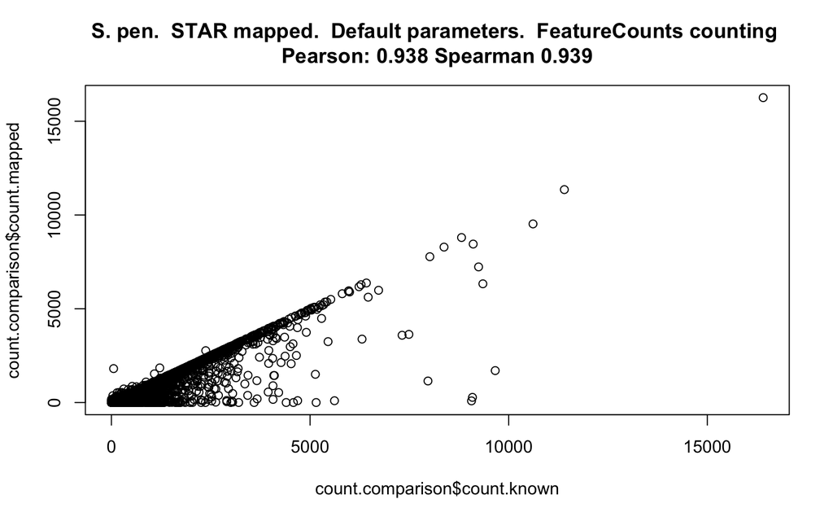

For many genes this is pretty good, but for some it is pretty poor. Is this due to S. pen?

# *S. lycopersicum*

Compare known to mapped counts

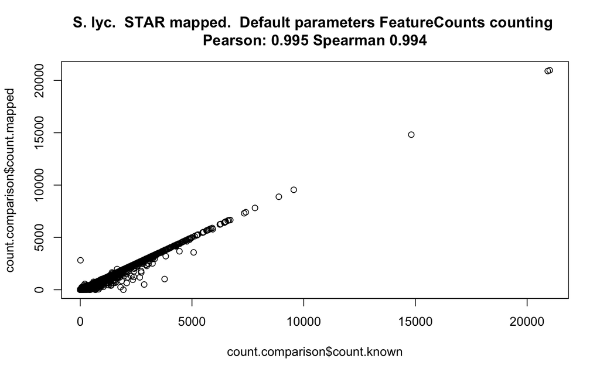

*S. lyc* maps much better. What is messing up the *S. pen* mapping?

# Investigate…

Lets take a look at the bam file and extract reads from a few genes with 0 mapped reads.

# Reads plotted by genes hit and mismatches

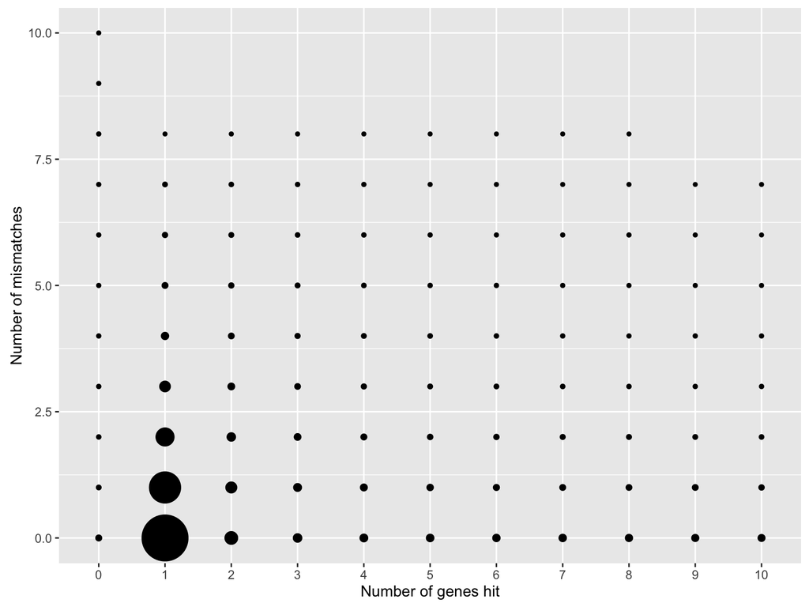

# Gene length effects

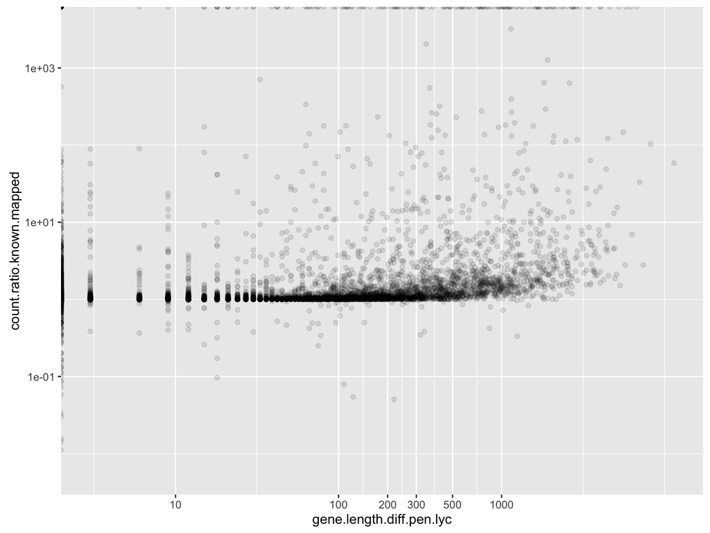

# Gene length effects 2

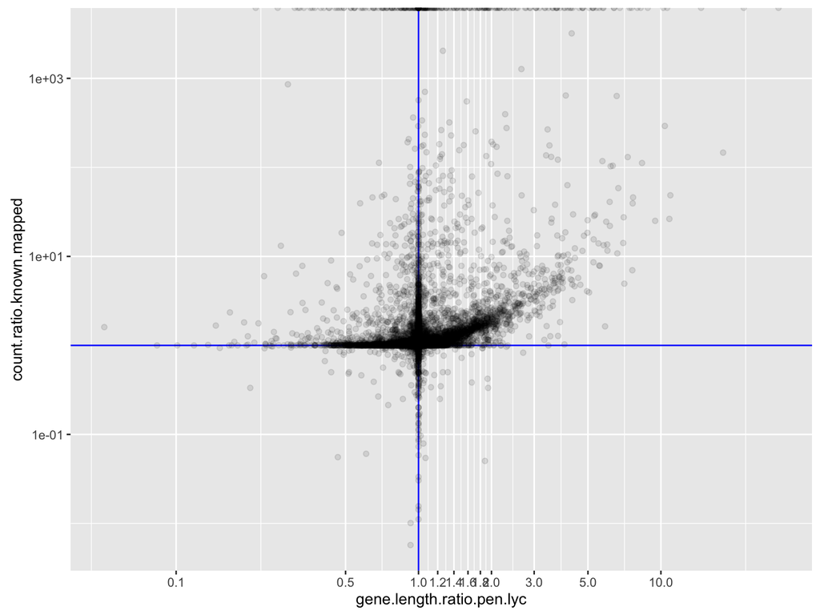

# Remove genes

Remove genes with gene length ratio > 1.3 or gene length difference > 300bp

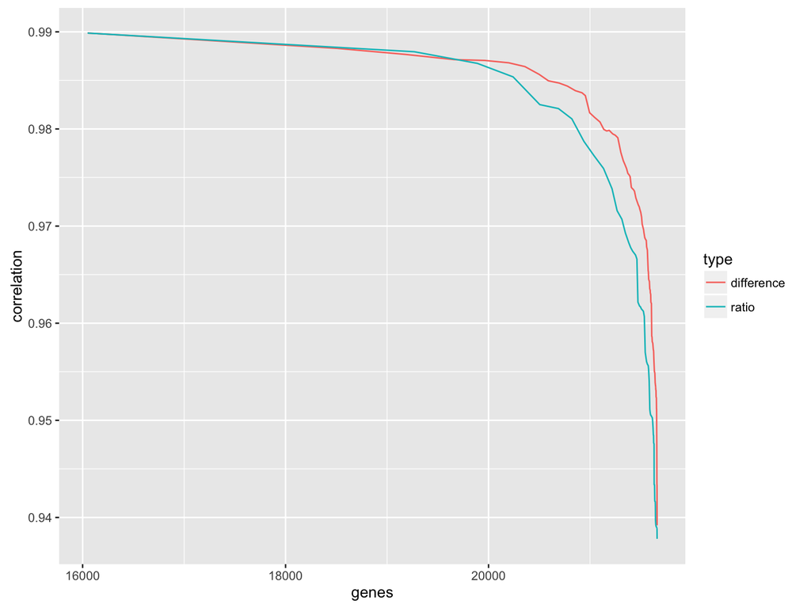

# how many reads map to the wrong gene?

# mismapping

Total mismapping

```r
with(reads.df.map.single.overlap,sum(mismap) / length(mismap))
```

```
## [1] 0.03214682
```

Of mismaps, what proportion map near to the correct gene:

```r
with(reads.df.map.single.overlap,sum(mapnear & mismap) / sum(mismap))
```

```
## [1] 0.696074
```

Proportion reads mapped to wrong gene (distant):

```r
sum(reads.df.map.single.overlap$mismap[!reads.df.map.single.overlap$mapnear]) / nrow(reads.df.map.single.overlap)
```

```
## [1] 0.009770255
```

# why mismapping?

Investigate by looking at where S.pen genes map on S.lyc chromosomes.

Are the S. pen “Orthlogs” really mapping to their cognate S.lyc gene?

Use BLAT to map S. pen predicted cDNAs to S. lyc genome.

# Map *real* reads as comparision

Now look in IGV (Note: Need to use IGVtools to sort and index the .psl file)

```r
head(reads.df.map.single.overlap[reads.df.map.single.overlap$mismap,c("qname","gene.lyc","gene.mapped.to","mapnear")],100)
```

```
##                                                                                qname
## 104688   read3816600;Sopen04g012680.1_Solyc04g025530.2.1;mate1:518-562;mate2:723-766
## 104689   read3816832;Sopen04g012680.1_Solyc04g025530.2.1;mate1:723-767;mate2:936-979
## 105406     read69730;Sopen01g001170.1_Solyc01g005140.2.1;mate1:198-242;mate2:381-424
## 107225 read3611020;Sopen04g003410.1_Solyc04g008290.2.1;mate1:840-884;mate2:1073-1116
## 108529   read3609833;Sopen04g003330.1_Solyc04g008210.1.1;mate1:568-612;mate2:809-852
## 116584     read76333;Sopen01g001290.1_Solyc01g005260.2.1;mate1:137-181;mate2:359-402
## 116594     read76843;Sopen01g001290.1_Solyc01g005260.2.1;mate1:128-172;mate2:350-393
## 116595     read76556;Sopen01g001290.1_Solyc01g005260.2.1;mate1:127-171;mate2:369-412
## 116596     read76729;Sopen01g001290.1_Solyc01g005260.2.1;mate1:126-170;mate2:321-364
## 116597     read76737;Sopen01g001290.1_Solyc01g005260.2.1;mate1:125-169;mate2:323-366
## 116598     read76609;Sopen01g001290.1_Solyc01g005260.2.1;mate1:124-168;mate2:359-402
## 116599     read76220;Sopen01g001290.1_Solyc01g005260.2.1;mate1:122-166;mate2:331-374
## 116600     read76235;Sopen01g001290.1_Solyc01g005260.2.1;mate1:122-166;mate2:382-425
## 116653      read76164;Sopen01g001290.1_Solyc01g005260.2.1;mate1:76-120;mate2:276-319
```

[output cut: 187 more lines]

```r
sort(table(reads.df.map.single.overlap$gene.lyc[reads.df.map.single.overlap$mismap]))
```

```
##
## Solyc01g005060.2.1 Solyc01g005140.2.1 Solyc01g005280.2.1
##                  1                  1                  1
## Solyc01g006120.2.1 Solyc01g006440.1.1 Solyc01g006490.2.1
##                  1                  1                  1
## Solyc01g006730.2.1 Solyc01g007070.2.1 Solyc01g007330.2.1
##                  1                  1                  1
## Solyc01g007340.2.1 Solyc01g008530.2.1 Solyc01g008640.2.1
##                  1                  1                  1
## Solyc01g008690.2.1 Solyc01g008840.2.1 Solyc01g009300.2.1
##                  1                  1                  1
## Solyc01g009360.1.1 Solyc01g009420.2.1 Solyc01g009530.1.1
##                  1                  1                  1
## Solyc01g010480.2.1 Solyc01g028930.2.1 Solyc01g044510.1.1
##                  1                  1                  1
## Solyc01g060020.2.1 Solyc01g066250.1.1 Solyc01g066620.2.1
##                  1                  1                  1
## Solyc01g067960.1.1 Solyc01g068150.2.1 Solyc01g068550.2.1
##                  1                  1                  1
## Solyc01g073750.2.1 Solyc01g073840.1.1 Solyc01g079670.2.1
##                  1                  1                  1
## Solyc01g079750.2.1 Solyc01g080910.2.1 Solyc01g081100.1.1
##                  1                  1                  1
## Solyc01g086990.2.1 Solyc01g087430.2.1 Solyc01g087680.2.1
##                  1                  1                  1
## Solyc01g088560.2.1 Solyc01g090430.2.1 Solyc01g090820.1.1
##                  1                  1                  1
## Solyc01g090990.2.1 Solyc01g091690.2.1 Solyc01g094070.2.1
##                  1                  1                  1
## Solyc01g094080.2.1 Solyc01g095100.2.1 Solyc01g095490.2.1
##                  1                  1                  1
## Solyc01g095830.2.1 Solyc01g095960.2.1 Solyc01g097610.2.1
##                  1                  1                  1
## Solyc01g098590.2.1 Solyc01g099200.2.1 Solyc01g099390.2.1
##                  1                  1                  1
## Solyc01g100530.2.1 Solyc01g100570.2.1 Solyc01g100800.1.1
##                  1                  1                  1
## Solyc01g103140.2.1 Solyc01g104800.2.1 Solyc01g105030.2.1
##                  1                  1                  1
## Solyc01g105050.2.1 Solyc01g106480.2.1 Solyc01g106750.1.1
```

[output cut: 2566 more lines]

```
##               1190               1274               1307
## Solyc03g097290.2.1 Solyc10g084140.1.1 Solyc01g094060.2.1
##               1317               1325               1328
## Solyc12g013680.1.1 Solyc01g005760.2.1 Solyc08g016050.2.1
##               1382               1391               1392
## Solyc01g105830.2.1 Solyc02g014190.2.1 Solyc02g079630.1.1
##               1412               1540               1548
## Solyc03g058550.1.1 Solyc01g110960.2.1 Solyc07g043620.2.1
##               1563               1830               1950
## Solyc04g049930.2.1 Solyc01g110010.2.1 Solyc01g111050.2.1
##               2147               2393               2502
## Solyc05g054880.2.1 Solyc04g076510.2.1 Solyc01g060040.2.1
##               2883               2942               2972
## Solyc04g050520.2.1 Solyc01g088170.2.1
##               3713               9272
```